# Gastos de Parlamentares de Janeiro a Maio de 2016

# Introdução

Os dados deste relatório foram coletados do site de transparência da câmara dos deputados. Esses dados contém todos os gastos de nossos deputados em 2016 de Janeiro a Maio, usando a sua cota para exercício da atividade parlamentar.

# Discurção dos Dados

Os dados abaixo mostram a distribuição dos gastos dos parlamenteres agrupados por partido e discriminando o tipo de gasto. Cada ponto no gráfico representa a soma de dos gastos, em milhares de reais, de todos os parlamentares de um partido X em um mês Y.

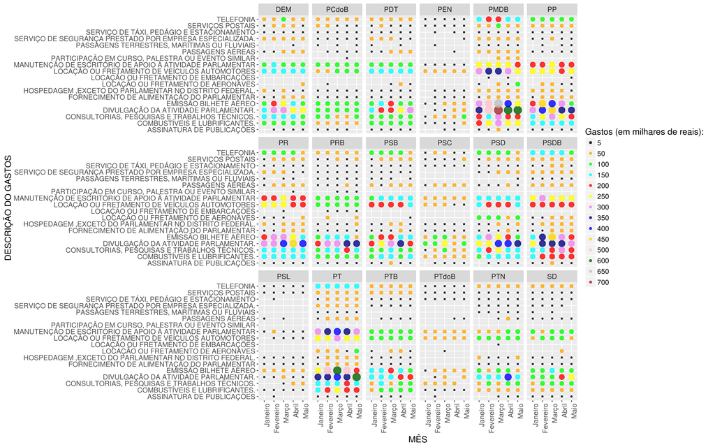

Observações:

- Os partidos analisados são aqueles que possuem um bancada com dez ou mais representantes na câmara federal;
- Os Gastos foram divididos em classes de intervalos de 50 mil reais;

# Conclusão

Várias informações sobre a distribuição dos gastos dos parlamentares podem ser extraidas do gráfico acima, por exemplo:

- Todos os partidos, exceto o PSL, o PTdoB e o PEN gastam mais com a divulgação de atividade parlamentar que qualquer outro tipo de gasto;
- O mês com a maior concentração de gastos é Março;
- O partido com os maiores gastos é o PMDB;
- etc.